# Análises CFEM

# Análise Univariada

Para identificar se os estados que seriam utilizados na modelagem conteriam o minímo de observações necessárias para a análise foi realizado o gráfico a seguir.

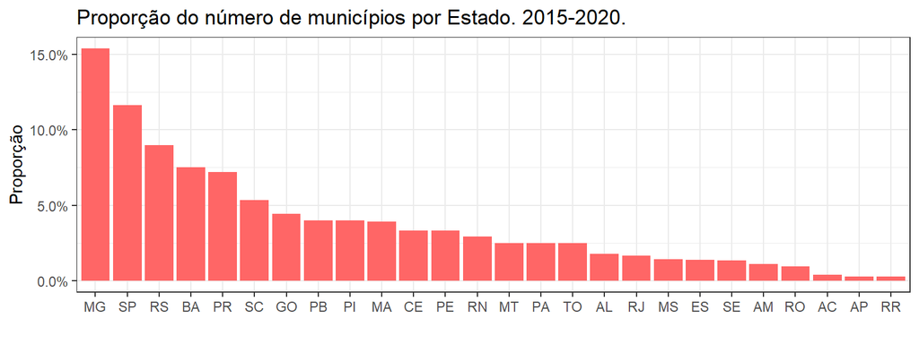

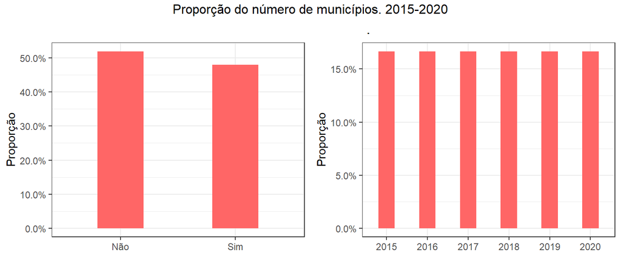

Para efeitos de análise será considerado:

0: quem não arrecada/distribui CFEM 1: quem arrecada/distribui CFEM

#### Distribuição do total de municípios por Estado segundo o recebimento ou não de CFEM. 2015-2020.

| UF | Sim_2015 | Nao_2015 | Sim_2016 | Nao_2016 | Sim_2017 | Nao_2017 | Sim_2018 | Nao_2018 | Sim_2019 | Nao_2019 | Sim_2020 | Nao_2020 |
| --- | --- | --- | --- | --- | --- | --- | --- | --- | --- | --- | --- | --- |
| AC | 7 | 15 | 4 | 18 | 6 | 16 | 5 | 17 | 6 | 16 | 6 | 16 |
| AL | 34 | 64 | 30 | 68 | 27 | 71 | 25 | 73 | 27 | 71 | 30 | 68 |
| AM | 24 | 37 | 19 | 42 | 20 | 41 | 23 | 38 | 20 | 41 | 24 | 37 |
| AP | 10 | 5 | 10 | 5 | 10 | 5 | 10 | 5 | 10 | 5 | 10 | 5 |
| BA | 169 | 248 | 165 | 252 | 179 | 238 | 178 | 239 | 212 | 205 | 223 | 194 |
| CE | 90 | 93 | 89 | 94 | 84 | 99 | 83 | 100 | 85 | 98 | 99 | 84 |
| ES | 62 | 15 | 64 | 13 | 64 | 13 | 65 | 12 | 65 | 12 | 70 | 7 |
| GO | 157 | 88 | 152 | 93 | 143 | 102 | 148 | 97 | 147 | 98 | 169 | 76 |
| MA | 38 | 178 | 40 | 176 | 42 | 174 | 45 | 170 | 64 | 152 | 69 | 147 |
| MG | 474 | 378 | 485 | 367 | 483 | 369 | 482 | 370 | 525 | 327 | 603 | 249 |
| MS | 48 | 31 | 50 | 29 | 56 | 23 | 57 | 22 | 54 | 25 | 62 | 17 |
| MT | 68 | 71 | 72 | 67 | 78 | 61 | 82 | 57 | 83 | 56 | 90 | 49 |
| PA | 60 | 79 | 62 | 77 | 59 | 80 | 63 | 76 | 67 | 72 | 73 | 66 |
| PB | 64 | 157 | 55 | 166 | 58 | 163 | 53 | 168 | 54 | 167 | 80 | 141 |
| PE | 70 | 113 | 67 | 116 | 65 | 118 | 58 | 125 | 67 | 116 | 66 | 117 |
| PI | 51 | 170 | 43 | 178 | 50 | 171 | 48 | 173 | 51 | 170 | 59 | 162 |
| PR | 177 | 222 | 175 | 224 | 179 | 220 | 183 | 216 | 189 | 210 | 201 | 198 |
| RJ | 68 | 23 | 66 | 25 | 66 | 25 | 65 | 26 | 71 | 20 | 76 | 15 |
| RN | 52 | 111 | 46 | 117 | 50 | 113 | 51 | 112 | 51 | 112 | 62 | 101 |
| RO | 33 | 19 | 34 | 18 | 32 | 20 | 32 | 20 | 34 | 18 | 38 | 14 |
| RR | 5 | 10 | 4 | 11 | 5 | 10 | 5 | 10 | 6 | 9 | 6 | 9 |
| RS | 204 | 293 | 213 | 284 | 209 | 288 | 208 | 289 | 217 | 280 | 237 | 260 |
| SC | 188 | 107 | 183 | 112 | 184 | 111 | 188 | 107 | 186 | 109 | 192 | 103 |
| SE | 34 | 41 | 35 | 40 | 33 | 42 | 31 | 44 | 31 | 44 | 28 | 47 |
| SP | 342 | 303 | 335 | 310 | 347 | 298 | 336 | 309 | 359 | 286 | 376 | 269 |
| TO | 37 | 102 | 39 | 100 | 36 | 103 | 41 | 98 | 41 | 98 | 55 | 84 |

#### Distribuição da proporção de municípios por Estado segundo o recebimento ou não de CFEM. 2015-2020.

|  | 2015 0 | 2015 1 | 2016 0 | 2016 1 | 2017 0 | 2017 1 | 2018 0 | 2018 1 | 2019 0 | 2019 1 | 2020 0 | 2020 1 |
| --- | --- | --- | --- | --- | --- | --- | --- | --- | --- | --- | --- | --- |
| AC | 0.68 | 0.32 | 0.82 | 0.18 | 0.73 | 0.27 | 0.77 | 0.23 | 0.73 | 0.27 | 0.73 | 0.27 |
| AL | 0.65 | 0.35 | 0.69 | 0.31 | 0.72 | 0.28 | 0.74 | 0.26 | 0.72 | 0.28 | 0.69 | 0.31 |
| AM | 0.61 | 0.39 | 0.69 | 0.31 | 0.67 | 0.33 | 0.62 | 0.38 | 0.67 | 0.33 | 0.61 | 0.39 |
| AP | 0.33 | 0.67 | 0.33 | 0.67 | 0.33 | 0.67 | 0.33 | 0.67 | 0.33 | 0.67 | 0.33 | 0.67 |
| BA | 0.59 | 0.41 | 0.60 | 0.40 | 0.57 | 0.43 | 0.57 | 0.43 | 0.49 | 0.51 | 0.47 | 0.53 |
| CE | 0.51 | 0.49 | 0.51 | 0.49 | 0.54 | 0.46 | 0.55 | 0.45 | 0.54 | 0.46 | 0.46 | 0.54 |
| ES | 0.19 | 0.81 | 0.17 | 0.83 | 0.17 | 0.83 | 0.16 | 0.84 | 0.16 | 0.84 | 0.09 | 0.91 |
| GO | 0.36 | 0.64 | 0.38 | 0.62 | 0.42 | 0.58 | 0.40 | 0.60 | 0.40 | 0.60 | 0.31 | 0.69 |
| MA | 0.82 | 0.18 | 0.81 | 0.19 | 0.81 | 0.19 | 0.79 | 0.21 | 0.70 | 0.30 | 0.68 | 0.32 |
| MG | 0.44 | 0.56 | 0.43 | 0.57 | 0.43 | 0.57 | 0.43 | 0.57 | 0.38 | 0.62 | 0.29 | 0.71 |
| MS | 0.39 | 0.61 | 0.37 | 0.63 | 0.29 | 0.71 | 0.28 | 0.72 | 0.32 | 0.68 | 0.22 | 0.78 |
| MT | 0.51 | 0.49 | 0.48 | 0.52 | 0.44 | 0.56 | 0.41 | 0.59 | 0.40 | 0.60 | 0.35 | 0.65 |
| PA | 0.57 | 0.43 | 0.55 | 0.45 | 0.58 | 0.42 | 0.55 | 0.45 | 0.52 | 0.48 | 0.47 | 0.53 |
| PB | 0.71 | 0.29 | 0.75 | 0.25 | 0.74 | 0.26 | 0.76 | 0.24 | 0.76 | 0.24 | 0.64 | 0.36 |
| PE | 0.62 | 0.38 | 0.63 | 0.37 | 0.64 | 0.36 | 0.68 | 0.32 | 0.63 | 0.37 | 0.64 | 0.36 |
| PI | 0.77 | 0.23 | 0.81 | 0.19 | 0.77 | 0.23 | 0.78 | 0.22 | 0.77 | 0.23 | 0.73 | 0.27 |
| PR | 0.56 | 0.44 | 0.56 | 0.44 | 0.55 | 0.45 | 0.54 | 0.46 | 0.53 | 0.47 | 0.50 | 0.50 |
| RJ | 0.25 | 0.75 | 0.27 | 0.73 | 0.27 | 0.73 | 0.29 | 0.71 | 0.22 | 0.78 | 0.16 | 0.84 |
| RN | 0.68 | 0.32 | 0.72 | 0.28 | 0.69 | 0.31 | 0.69 | 0.31 | 0.69 | 0.31 | 0.62 | 0.38 |
| RO | 0.37 | 0.63 | 0.35 | 0.65 | 0.38 | 0.62 | 0.38 | 0.62 | 0.35 | 0.65 | 0.27 | 0.73 |
| RR | 0.67 | 0.33 | 0.73 | 0.27 | 0.67 | 0.33 | 0.67 | 0.33 | 0.60 | 0.40 | 0.60 | 0.40 |
| RS | 0.59 | 0.41 | 0.57 | 0.43 | 0.58 | 0.42 | 0.58 | 0.42 | 0.56 | 0.44 | 0.52 | 0.48 |
| SC | 0.36 | 0.64 | 0.38 | 0.62 | 0.38 | 0.62 | 0.36 | 0.64 | 0.37 | 0.63 | 0.35 | 0.65 |
| SE | 0.55 | 0.45 | 0.53 | 0.47 | 0.56 | 0.44 | 0.59 | 0.41 | 0.59 | 0.41 | 0.63 | 0.37 |
| SP | 0.47 | 0.53 | 0.48 | 0.52 | 0.46 | 0.54 | 0.48 | 0.52 | 0.44 | 0.56 | 0.42 | 0.58 |
| TO | 0.73 | 0.27 | 0.72 | 0.28 | 0.74 | 0.26 | 0.71 | 0.29 | 0.71 | 0.29 | 0.60 | 0.40 |

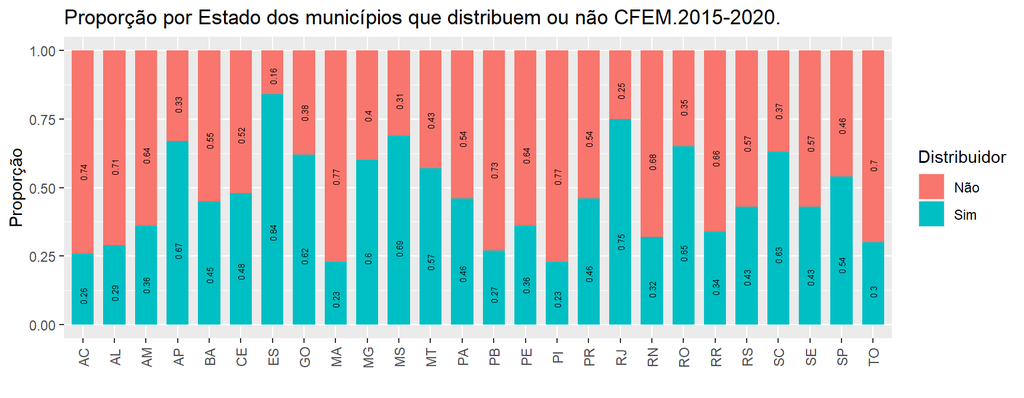

# Análise bivariada: variáveis explicativas versus resposta.

##Investimentos per capita versus distribuição de CFEM

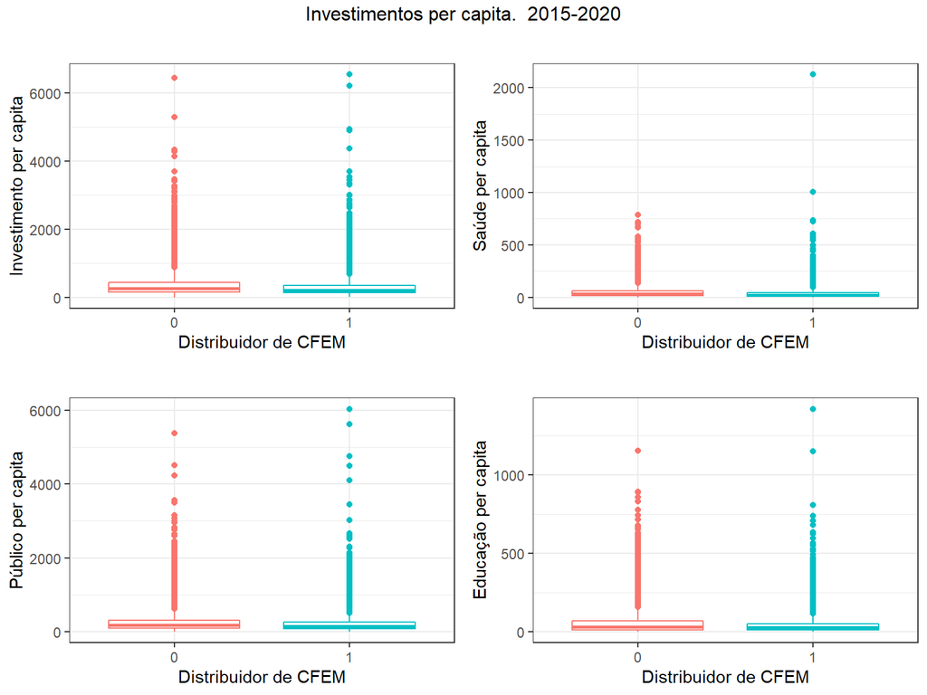

## Investimentos per capita versus Unidade da Federação

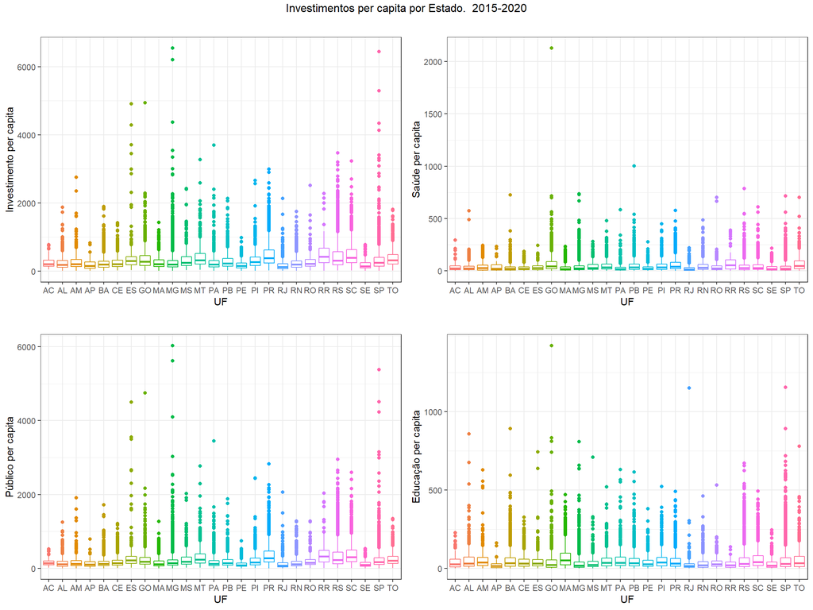